# Mechanism of action Dataset Exploratory Data Analysis(EDA)

# Effect of cp_time and cp_dose on gene and cell viablity data

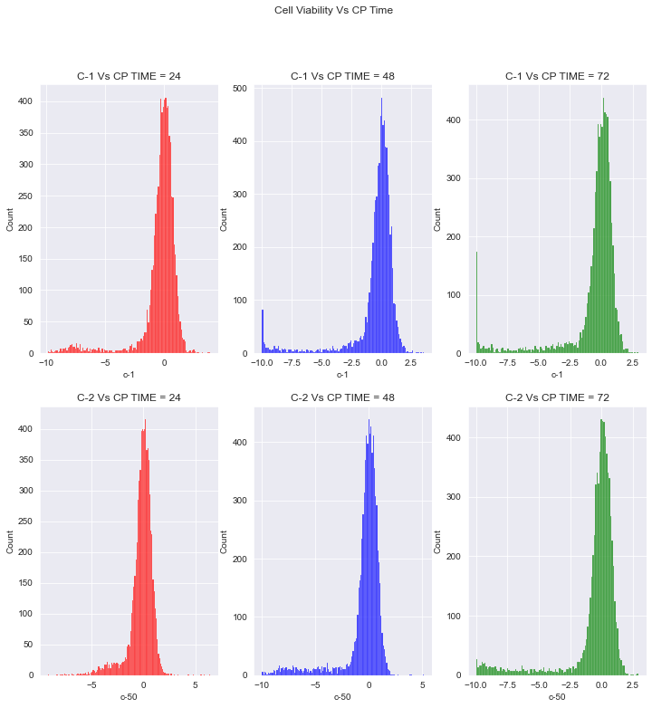

```python
# Effect of cp_time on  random cell viablity
plt.figure(figsize = (12,12))

plt.subplot(2,3,1)
c_1 = train_data[["c-1","cp_time"]]
c_1_24 = c_1[c_1["cp_time"]==24]
sns.histplot(c_1_24["c-1"],color = "red")
plt.title("C-1 Vs CP TIME = 24")

plt.subplot(2,3,2)
c_1_48 = c_1[c_1["cp_time"]==48]
sns.histplot(c_1_48["c-1"],color = "blue")
plt.title("C-1 Vs CP TIME = 48")


plt.subplot(2,3,3)
c_1_72 = c_1[c_1["cp_time"]==72]
sns.histplot(c_1_72["c-1"],color = "green")
plt.title("C-1 Vs CP TIME = 72")

plt.subplot(2,3,4)
c_2 = train_data[["c-50","cp_time"]]
c_2_24 = c_2[c_2["cp_time"]==24]
sns.histplot(c_2_24["c-50"],color = "red")
plt.title("C-2 Vs CP TIME = 24")

plt.subplot(2,3,5)
c_2_48 = c_2[c_2["cp_time"]==48]
sns.histplot(c_2_48["c-50"],color = "blue")
plt.title("C-2 Vs CP TIME = 48")


plt.subplot(2,3,6)
c_2_72 = c_2[c_2["cp_time"]==72]
sns.histplot(c_2_72["c-50"],color = "green")
plt.title("C-2 Vs CP TIME = 72")

plt.suptitle("Cell Viability Vs CP Time")

plt.show()
```

We can say from above graph that there is an increase in negative cell viablity as the time duration increases.

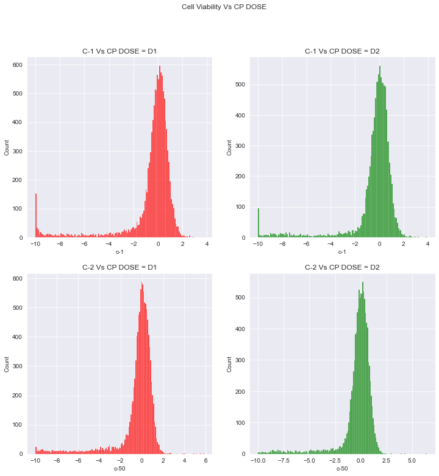

```python
# Effect of cp_dose on  randomcell viablity
plt.figure(figsize = (12,12))

plt.subplot(2,2,1)
c_1 = train_data[["c-1","cp_dose"]]
c_1_D1 = c_1[c_1["cp_dose"]=="D1"]
sns.histplot(c_1_D1["c-1"],color = "red")
plt.title("C-1 Vs CP DOSE = D1")

plt.subplot(2,2,2)
c_1_D2 = c_1[c_1["cp_dose"]=="D2"]
sns.histplot(c_1_D2["c-1"],color = "green")
plt.title("C-1 Vs CP DOSE = D2")

plt.subplot(2,2,3)
c_2 = train_data[["c-50","cp_dose"]]
c_2_D2 = c_2[c_2["cp_dose"]=="D1"]
sns.histplot(c_2_D2["c-50"],color = "red")
plt.title("C-2 Vs CP DOSE = D1")

plt.subplot(2,2,4)
c_2_D2 = c_2[c_2["cp_dose"]=="D2"]
sns.histplot(c_2_D2["c-50"],color = "green")
plt.title("C-2 Vs CP DOSE = D2")

plt.suptitle("Cell Viability Vs CP DOSE")

plt.show()
```

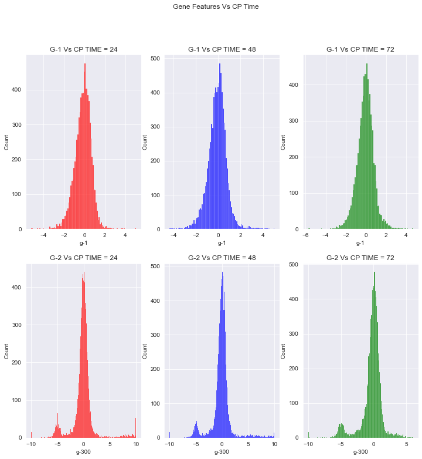

```python
## Effect of cp_time on  random Gene data
plt.figure(figsize = (12,12))

plt.subplot(2,3,1)
g_1 = train_data[["g-1","cp_time"]]
g_1_24 = g_1[g_1["cp_time"]==24]
sns.histplot(g_1_24["g-1"],color = "red")
plt.title("G-1 Vs CP TIME = 24")

plt.subplot(2,3,2)
g_1_48 = g_1[g_1["cp_time"]==48]
sns.histplot(g_1_48["g-1"],color = "blue")
plt.title("G-1 Vs CP TIME = 48")


plt.subplot(2,3,3)
g_1_72 = g_1[g_1["cp_time"]==72]
sns.histplot(g_1_72["g-1"],color = "green")
plt.title("G-1 Vs CP TIME = 72")

plt.subplot(2,3,4)
g_2 = train_data[["g-300","cp_time"]]
g_2_24 = g_2[g_2["cp_time"]==24]
sns.histplot(g_2_24["g-300"],color = "red")
plt.title("G-2 Vs CP TIME = 24")

plt.subplot(2,3,5)
g_2_48 = g_2[g_2["cp_time"]==48]
sns.histplot(g_2_48["g-300"],color = "blue")
plt.title("G-2 Vs CP TIME = 48")


plt.subplot(2,3,6)
g_2_72 = g_2[g_2["cp_time"]==72]
sns.histplot(g_2_72["g-300"],color = "green")
plt.title("G-2 Vs CP TIME = 72")

plt.suptitle("Gene Features Vs CP Time")

plt.show()
```

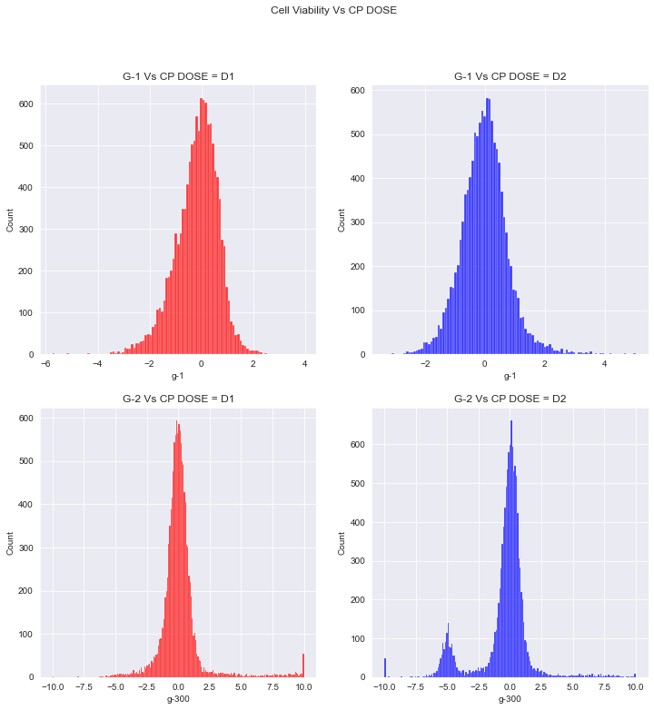

```python
# Effect of cp_dose on random Gene data
plt.figure(figsize = (12,12))

plt.subplot(2,2,1)
g_1 = train_data[["g-1","cp_dose"]]
g_1_D1 = g_1[g_1["cp_dose"]=="D1"]
sns.histplot(g_1_D1["g-1"],color = "red")
plt.title("G-1 Vs CP DOSE = D1")

plt.subplot(2,2,2)
g_1_D2 = g_1[g_1["cp_dose"]=="D2"]
sns.histplot(g_1_D2["g-1"],color = "blue")
plt.title("G-1 Vs CP DOSE = D2")

plt.subplot(2,2,3)
g_2 = train_data[["g-300","cp_dose"]]
g_2_D1 = g_2[g_2["cp_dose"]=="D1"]
sns.histplot(g_2_D1["g-300"],color = "red")
plt.title("G-2 Vs CP DOSE = D1")

plt.subplot(2,2,4)
g_2_D2 = g_2[g_2["cp_dose"]=="D2"]
sns.histplot(g_2_D2["g-300"],color = "blue")
plt.title("G-2 Vs CP DOSE = D2")

plt.suptitle("Cell Viability Vs CP DOSE")

plt.show()
```

# Correlations

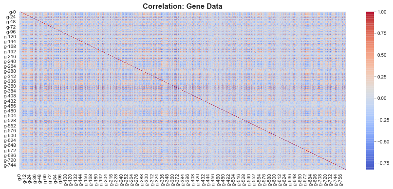

```python
# Correlations between genes

gene = train_data.iloc[1:3624 ,4:771]
plt.figure(figsize=(15,6))
sns.heatmap(gene.corr(),cmap='coolwarm',alpha=0.75)
plt.title('Correlation: Gene Data', fontsize=15, weight='bold')
plt.show()
```

```python
def diagonal_pairs(df):
    drop_pairs = set()
    x = df.columns
    for i in range(0, df.shape[1]):
        for j in range(0, i+1):
            drop_pairs.add((x[i], x[j]))
    return drop_pairs
def correlations(df,n=5):
    top_corr = df.corr().abs().unstack()
    labels_to_drop = diagonal_pairs(df)
    top_corr = top_corr.drop(labels=labels_to_drop).sort_values(ascending=False)
    return top_corr[0:n]

diagonal_pairs(gene)
print(correlations(gene, 10))
```

```
g-37   g-50     0.906424
g-349  g-460    0.857138
g-50   g-489    0.851010
g-37   g-489    0.850305
g-369  g-569    0.846992
g-50   g-672    0.842562
g-248  g-460    0.840229
g-123  g-744    0.830518
g-63   g-195    0.828375
g-38   g-744    0.826617
dtype: float64
```

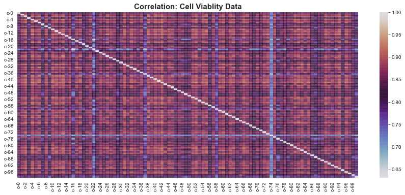

```python
#Correlation between cells
cell = train_data.iloc[1:3624 ,776:876]
plt.figure(figsize=(15,6))
sns.heatmap(cell.corr(),cmap='twilight',alpha=0.75)
plt.title('Correlation: Cell Viablity Data', fontsize=15, weight='bold')
plt.show()
```

```python
diagonal_pairs(cell)
print(correlations(cell, 10))
```

```
c-42  c-52    0.928782
c-4   c-13    0.926462
c-13  c-26    0.924563
c-4   c-42    0.924094
c-38  c-63    0.923631
c-13  c-73    0.923532
c-4   c-52    0.920889
c-2   c-38    0.920750
c-11  c-55    0.920345
c-4   c-55    0.920303
dtype: float64
```

Both Gene data and cell viablity data shows good correlation within them, but we can see from above that there is higher degree of correlation between Cell viablity data than Gene data.

# Target variable

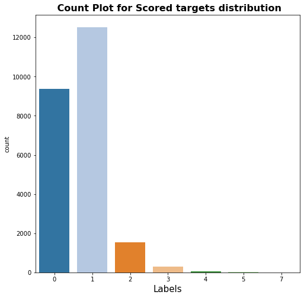

```python
# Plotting distribution of target variables
plt.figure(figsize=(8,8))
sns.countplot(target_data.sum(axis=1))
plt.xlabel('Labels',fontsize=15)
plt.title(" Count Plot for Scored targets distribution", fontsize=16, weight='bold')
plt.show()
```

From the above graph we can see that most of the drugs have atleast one target site. Although some drugs have more than one target site, its very negligeble compared to "0" and "1". Also some targets are repeated more often than others. We can have a look at them in our further analysis.

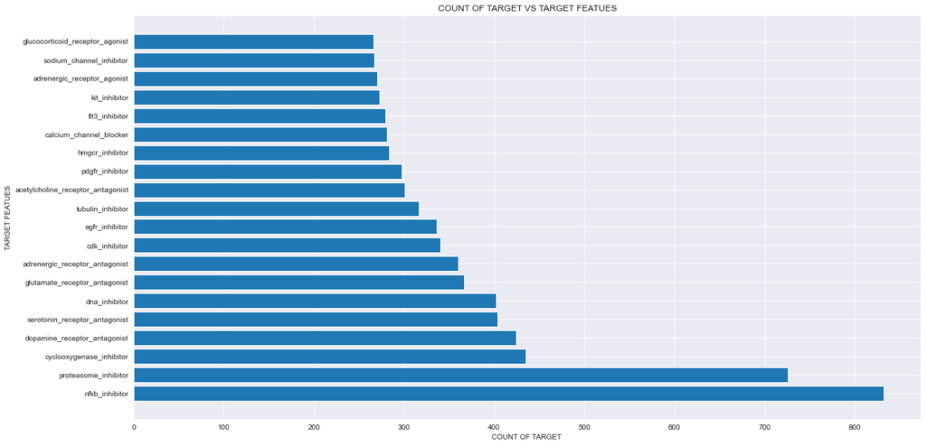

```python
# Sorting targets
x_axis = list(target_data.columns.values)
sig_id_values  = x_axis[1:]
len(sig_id_values) , sig_id_values[:4]
count_of_target = target_data.iloc[:,1:].sum().values
len(count_of_target) , count_of_target[:3]
dct =dict(zip(sig_id_values, count_of_target))
sorted_dict = dict( sorted(dct.items(), key=lambda i: i[1], reverse=True))

#TOP 20 TARGETS OCCURING MORE FREQUNTLY WITH THEIR COUNTS
list(sorted_dict.items())[:20]
plt.figure(figsize=(19,10))
plt.barh(list(sorted_dict.keys())[:20], list(sorted_dict.values())[:20] )
plt.title('COUNT OF TARGET VS TARGET FEATUES')
plt.xlabel('COUNT OF TARGET ')
plt.ylabel('TARGET FEATUES')
plt.show()
```

We can conclude from above graph that we have two target features which have more common occurence i.e nkfb_inhibitor and proteasome_inhibitor.

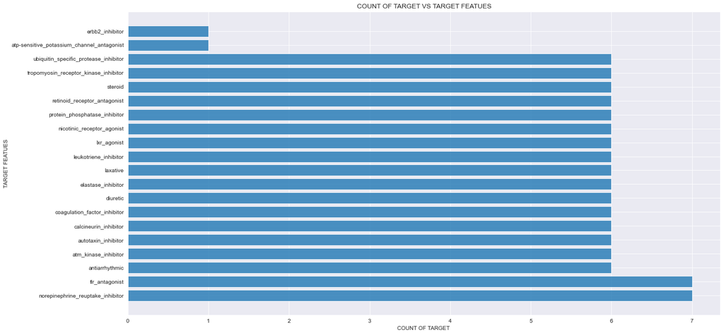

```python
#LEAST 20 TARGETS OCCURING MORE FREQUNTLY WITH THEIR COUNTS
plt.figure(figsize=(19,10))
plt.barh(list(sorted_dict.keys())[-20:], list(sorted_dict.values())[-20:],alpha=0.8 )
plt.title('COUNT OF TARGET VS TARGET FEATUES')
plt.xlabel('COUNT OF TARGET ')
plt.ylabel('TARGET FEATUES')
plt.show()
```

We can conclude from above graph that we have two target features which have only one occurence i.e erbb2_inhibitor and atp_sensitive_pottasium_channel_antagonist.

Outliers would not be removed from the dataset since they are important observations, and give meaningful insights to the dataset.

# Correlations

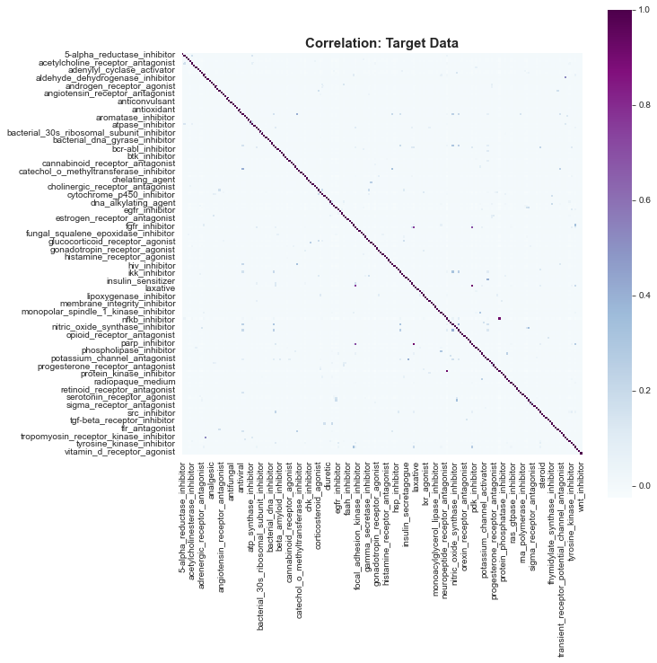

```python
#Correlations within target variables
new_target_data = target_data.drop(["sig_id"], axis=1)
correlation_target= new_target_data.corr()
plt.figure(figsize= (10,10))
sns.heatmap(correlation_target, square= True,cmap=plt.cm.BuPu)
plt.title('Correlation: Target Data', fontsize=15, weight='bold')
plt.show()
```

There is very less correlations among the target variables.

```python
diagonal_pairs(correlation_target)
print(correlations(correlation_target, 10))
```

```
kit_inhibitor                      pdgfr_inhibitor                      0.994601
nfkb_inhibitor                     proteasome_inhibitor                 0.990562
flt3_inhibitor                     kit_inhibitor                        0.951336
                                   pdgfr_inhibitor                      0.936127
aldehyde_dehydrogenase_inhibitor   trpv_agonist                         0.820699
nitric_oxide_production_inhibitor  nrf2_activator                       0.743302
insulin_sensitizer                 ppar_receptor_agonist                0.666296
apoptosis_stimulant                caspase_activator                    0.661034
ikk_inhibitor                      nitric_oxide_production_inhibitor    0.631186
bcl_inhibitor                      nitric_oxide_production_inhibitor    0.623893
dtype: float64
```

There are very few highly correlated pairs in target dataset.

# Correlatrion between Training data features and Target data features

```python
# Converting cp_time and cp_dose to categorical variable
train_data = train_data[train_data['cp_type']!='ctl_vehicle']
dummy_data = pd.get_dummies(train_data, columns=["cp_type","cp_time","cp_dose"])

# Merge two data frames of train_data and target_data
new_train_data = dummy_data.merge(target_data, on = "sig_id")


# Removed sig_id from above dataframe
mixed_correlation = new_train_data.drop(["sig_id"], axis=1)
```

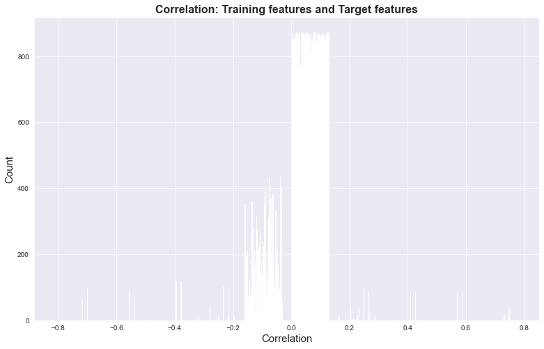

```python
#correlation between train data and target features
%matplotlib inline
correlation_data= mixed_correlation.corr()
correlation_data_new =correlation_data.iloc[:875,875:]
plt.figure(figsize= (13,8))
plt.hist(correlation_data_new)
plt.ylabel('Count',fontsize=15)
plt.xlabel('Correlation',fontsize=15)
plt.title('Correlation: Training features and Target features', fontsize=16, weight='bold')
plt.show()
```

The above plot gives us representation of correlation between Train data features and target features. We have some highly positive correlation and some highly negative correlation. Most of the data is weekly correlated, but we can sort some correlation among them in our further analysis.

```python
# Highly correlated Train features and target features
sort_corr = correlation_data_new.abs().unstack()
sort_corr.sort_values(ascending = False).drop_duplicates()[:40]
```

```
proteasome_inhibitor  c-78     0.819816
                      c-32     0.804192
                      c-53     0.798831
                      c-31     0.798461
                      g-349    0.789331
                      c-16     0.789159
                      c-83     0.787470
                      c-85     0.784811
                      c-88     0.783706
                      c-44     0.782305
                      c-35     0.782141
                      c-93     0.780356
                      c-17     0.778975
                      c-90     0.774141
                      c-72     0.772406
                      c-61     0.772351
                      c-27     0.772269
                      c-68     0.770052
                      c-14     0.767815
nfkb_inhibitor        c-78     0.763313
proteasome_inhibitor  c-60     0.762756
                      c-89     0.762513
                      c-20     0.759261
                      c-96     0.759235
                      c-62     0.758731
                      c-91     0.757027
                      c-2      0.756935
                      c-39     0.756016
                      c-0      0.753974
                      c-70     0.753527
                      c-75     0.748981
nfkb_inhibitor        c-32     0.748832
proteasome_inhibitor  c-52     0.745403
nfkb_inhibitor        c-53     0.745398
proteasome_inhibitor  c-11     0.745105
                      c-55     0.744598
nfkb_inhibitor        c-31     0.744336
proteasome_inhibitor  c-12     0.742941
                      c-33     0.742243
                      c-97     0.741922
dtype: float64
```

```python
 # least correlated Train features and target features
sort_corr = correlation_data_new.abs().unstack()
sort_corr.sort_values(ascending = True).drop_duplicates()[:40]
```

```
beta_amyloid_inhibitor                     g-217    3.928972e-08
acat_inhibitor                             g-255    1.142334e-07
benzodiazepine_receptor_agonist            g-481    3.948857e-07
beta_amyloid_inhibitor                     g-345    4.094129e-07
hcv_inhibitor                              g-373    4.442083e-07
cck_receptor_antagonist                    g-253    4.911229e-07
antihistamine                              g-23     5.000695e-07
insulin_secretagogue                       g-251    5.217303e-07
potassium_channel_activator                g-649    5.558960e-07
analgesic                                  c-58     5.720282e-07
progesterone_receptor_antagonist           g-765    5.808323e-07
apoptosis_stimulant                        g-536    7.234841e-07
analgesic                                  g-383    7.659585e-07
antihistamine                              g-584    8.081027e-07
diuretic                                   g-13     8.622598e-07
ubiquitin_specific_protease_inhibitor      g-455    9.422703e-07
acat_inhibitor                             g-87     1.010965e-06
serotonin_reuptake_inhibitor               g-85     1.249700e-06
cannabinoid_receptor_agonist               g-530    1.279710e-06
casein_kinase_inhibitor                    g-554    1.326017e-06
dopamine_receptor_antagonist               g-397    1.437945e-06
norepinephrine_reuptake_inhibitor          g-266    1.627726e-06
potassium_channel_antagonist               g-622    1.637583e-06
antiviral                                  g-39     1.692414e-06
p38_mapk_inhibitor                         g-391    1.696429e-06
adenylyl_cyclase_activator                 g-548    1.773567e-06
smoothened_receptor_antagonist             g-499    1.982014e-06
5-alpha_reductase_inhibitor                g-245    2.017049e-06
bcr-abl_inhibitor                          c-93     2.110219e-06
analgesic                                  g-275    2.168698e-06
acat_inhibitor                             g-753    2.182708e-06
aurora_kinase_inhibitor                    g-203    2.226476e-06
gaba_receptor_antagonist                   g-240    2.259478e-06
pdk_inhibitor                              g-591    2.433704e-06
bacterial_50s_ribosomal_subunit_inhibitor  g-727    2.465130e-06
p38_mapk_inhibitor                         g-612    2.495326e-06
dipeptidyl_peptidase_inhibitor             g-236    2.554344e-06
tgf-beta_receptor_inhibitor                g-23     2.576109e-06
bromodomain_inhibitor                      g-163    2.629924e-06
steroid                                    g-430    2.640644e-06
dtype: float64
```

From the above analysis for correlation between train features and target features we can conclude that there Gene expression and cell viablity data can be used to predict target site of an drug with unknown mechanism of action.

# Test data

There are three categorical features in test data i.e cp_type, cp_time, cp_dose

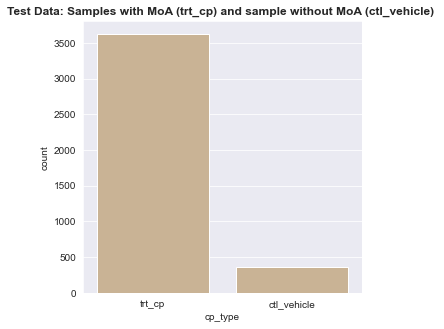

```python
# cp_type
test_data.cp_type.astype("category")
plt.figure(figsize=(5,5))
sns.set_palette("tab20")
sns.countplot(test_data['cp_type'], color='tan')
plt.title("Test Data: Samples with MoA (trt_cp) and sample without MoA (ctl_vehicle) ", fontsize=12, weight='bold')
plt.show()
```

As we can see that cp_type is imbalanced whith high number of trt*cp, which is expected since it has MoA. As we know ctl* vehcicle has no MoA, so it will of no use to us and we will discard it from our dataset for our further analysis

```python
# remove ctl_vehicle from train data
test_data= test_data.drop(test_data[test_data.cp_type == "ctl_vehicle"].index)
test_data_dummie = pd.get_dummies(test_data, columns=["cp_type","cp_time","cp_dose"])
test_data_dummie
```

|  | sig_id | g-0 | g-1 | g-2 | g-3 | g-4 | g-5 | g-6 | g-7 | g-8 | ... | c-96 | c-97 | c-98 | c-99 | cp_type_trt_cp | cp_time_24 | cp_time_48 | cp_time_72 | cp_dose_D1 | cp_dose_D2 |
| --- | --- | --- | --- | --- | --- | --- | --- | --- | --- | --- | --- | --- | --- | --- | --- | --- | --- | --- | --- | --- | --- |
| 0 | id_0004d9e33 | -0.5458 | 0.1306 | -0.5135 | 0.4408 | 1.5500 | -0.1644 | -0.2140 | 0.2221 | -0.3260 | ... | 0.0210 | -0.0502 | 0.1510 | -0.7750 | 1 | 1 | 0 | 0 | 1 | 0 |
| 1 | id_001897cda | -0.1829 | 0.2320 | 1.2080 | -0.4522 | -0.3652 | -0.3319 | -1.8820 | 0.4022 | -0.3528 | ... | 0.0359 | -0.4764 | -1.3810 | -0.7300 | 1 | 0 | 0 | 1 | 1 | 0 |
| 3 | id_00276f245 | 0.4828 | 0.1955 | 0.3825 | 0.4244 | -0.5855 | -1.2020 | 0.5998 | -0.1799 | 0.9365 | ... | 0.8131 | -0.1305 | 0.5645 | -0.5809 | 1 | 1 | 0 | 0 | 0 | 1 |
| 4 | id_0027f1083 | -0.3979 | -1.2680 | 1.9130 | 0.2057 | -0.5864 | -0.0166 | 0.5128 | 0.6365 | 0.2611 | ... | -0.2962 | -0.5313 | 0.9931 | 1.8380 | 1 | 0 | 1 | 0 | 1 | 0 |
| 6 | id_006fc47b8 | 0.3658 | 0.5536 | -0.6898 | -1.6270 | 0.5239 | -0.3832 | -0.4653 | 1.0070 | 0.3726 | ... | -0.2593 | -0.2174 | 0.0044 | -1.4650 | 1 | 0 | 1 | 0 | 0 | 1 |
| ... | ... | ... | ... | ... | ... | ... | ... | ... | ... | ... | ... | ... | ... | ... | ... | ... | ... | ... | ... | ... | ... |
| 3977 | id_ff7004b87 | 0.4571 | -0.5743 | 3.3930 | -0.6202 | 0.8557 | 1.6240 | 0.0640 | -0.6316 | -1.1990 | ... | -1.2680 | -1.1280 | -0.4167 | -0.6600 | 1 | 1 | 0 | 0 | 1 | 0 |
| 3978 | id_ff925dd0d | -0.5885 | -0.2548 | 2.5850 | 0.3456 | 0.4401 | 0.3107 | -0.7437 | -0.0143 | 0.2615 | ... | 0.2614 | -0.2790 | -0.0131 | -0.0934 | 1 | 1 | 0 | 0 | 1 | 0 |
| 3979 | id_ffb710450 | -0.3985 | -0.1554 | 0.2677 | -0.6813 | 0.0152 | 0.4791 | -0.0166 | 0.7501 | 0.0346 | ... | 0.0461 | 0.5888 | -0.4205 | -0.1504 | 1 | 0 | 0 | 1 | 1 | 0 |
| 3980 | id_ffbb869f2 | -1.0960 | -1.7750 | -0.3977 | 1.0160 | -1.3350 | -0.2207 | -0.3611 | -1.3020 | 1.0150 | ... | -0.2618 | 0.5074 | 0.7430 | -0.0484 | 1 | 0 | 1 | 0 | 0 | 1 |
| 3981 | id_ffd5800b6 | -0.5174 | 0.2953 | 0.3286 | -0.0428 | -0.0800 | 0.8702 | -0.8724 | 0.3883 | -0.0491 | ... | -0.4948 | 0.0757 | -0.1356 | 0.5280 | 1 | 0 | 0 | 1 | 1 | 0 |

3624 rows × 879 columns

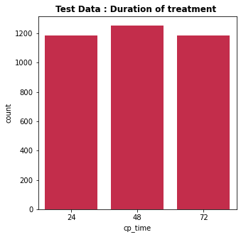

```python
#cp_time
test_data.cp_time.astype("category")
plt.figure(figsize=(5,5))
sns.set_palette("tab20")
sns.countplot(test_data['cp_time'], color='crimson')
plt.title("Test Data : Duration of treatment ", fontsize=12, weight='bold')
plt.show()
# Treatment durations are pretty balanced for our dataset
```

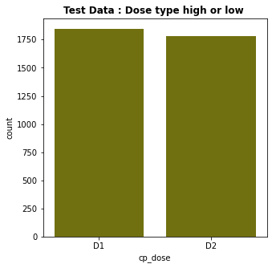

```python
test_data.cp_dose.astype("category")
plt.figure(figsize=(5,5))
sns.set_palette("tab20")
sns.countplot(test_data['cp_dose'], color='olive')
plt.title("Test Data : Dose type high or low ", fontsize=12, weight='bold')
plt.show()
#Dose type are pretty balanced and evenly distributed for our dataset
```

# Distribution of Gene in Test data

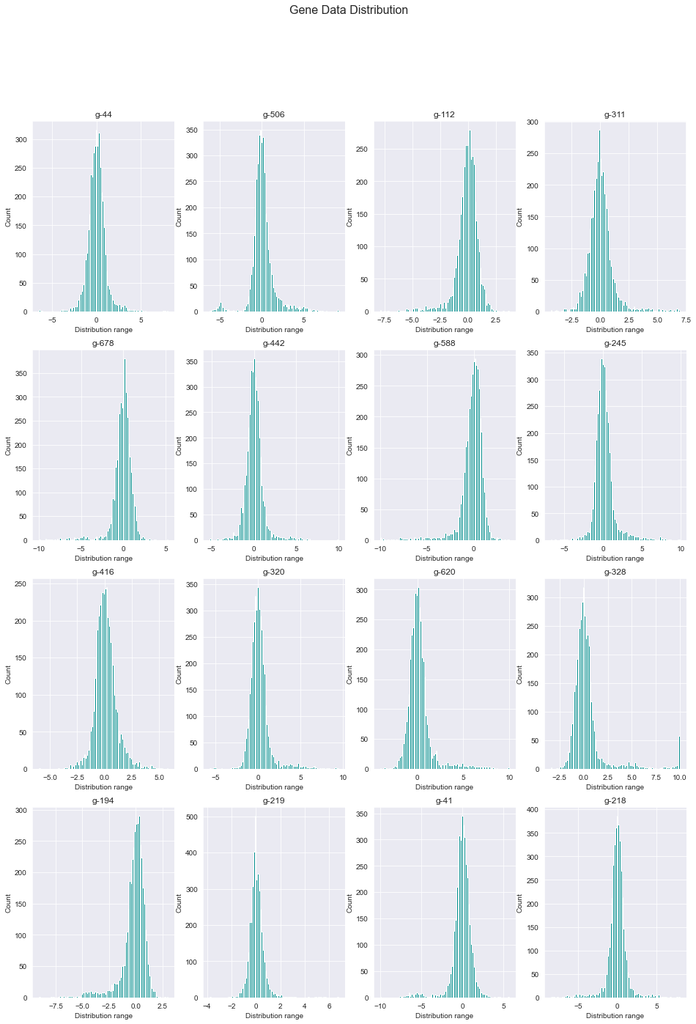

```python
gene_test = [g for g in test_data.columns if g.startswith("g-")]
plt.figure(figsize=(16,22))
sns.set_style('darkgrid')
gene_distribution_test =np.random.choice(len(gene_test),16)
for i,col in enumerate(gene_distribution_test):
    plt.subplot(4,4,i+1)
    plt.suptitle("Gene Data Distribution", fontsize=16)
    plt.ylabel('Count',fontsize=10)
    plt.xlabel('Distribution range',fontsize=10)
    plt.hist(test_data.loc[:,gene_test[col]],bins=100,color="darkcyan")
    plt.title(gene_test[col])
```

From above data we can see that the range for -10 to 10. Negative value indicates gene supression and positive value indicates gene expression

# Distribution of cell viablity in Test data

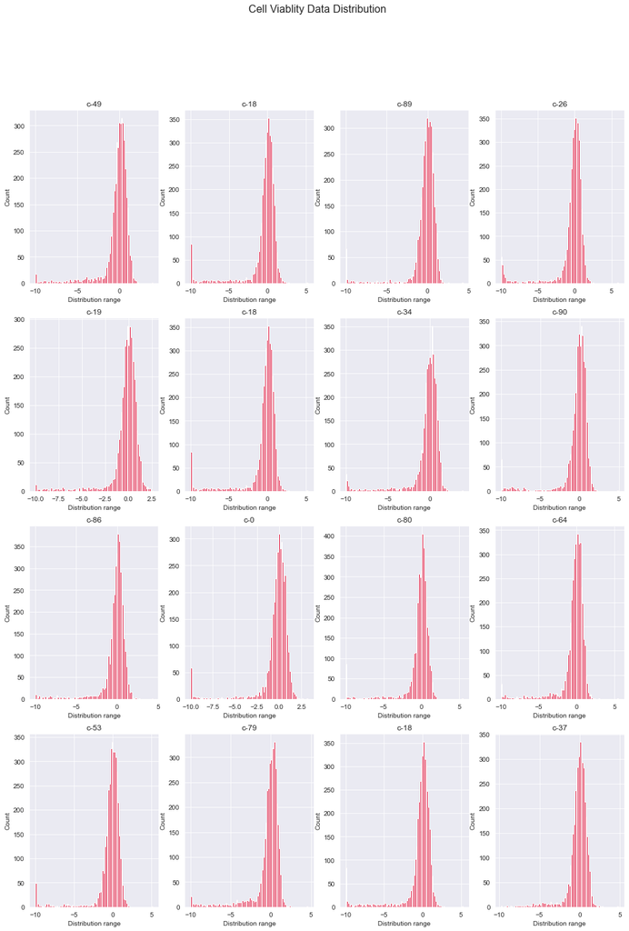

```python
cell_test = [c for c in test_data.columns if c.startswith("c-")]
plt.figure(figsize=(16,22))
sns.set_style('darkgrid')
cell_distribution_test =np.random.choice(len(cell_test),16)
for i,col in enumerate(cell_distribution_test):
    plt.subplot(4,4,i+1)
    plt.suptitle("Cell Viablity Data Distribution", fontsize=16)
    plt.ylabel('Count',fontsize=10)
    plt.xlabel('Distribution range',fontsize=10)
    plt.hist(test_data.loc[:,cell_test[col]],bins=100,color="crimson")
    plt.title(cell_test[col])
```

From above data we can see that the range for -10 to 10. Negative value indicates dead cells and positive value indicates living cells.

Thus we can say that both test data and train data has gene data and cell viablity data within the range of -10 to 10.

# Correlation within Gene data and Cellvibality data

```python
#Correlation within Gene data
gene_test = test_data.iloc[1:3624 ,4:771]
diagonal_pairs(gene_test)
print(correlations(gene_test, 10))
```

```
g-37   g-50     0.912476
g-123  g-744    0.854028
g-349  g-460    0.853764
g-50   g-672    0.852693
g-369  g-569    0.851348
g-63   g-195    0.850437
g-228  g-349    0.846350
g-195  g-228    0.844091
g-248  g-460    0.842553
g-228  g-744    0.841331
dtype: float64
```

```python
#Correlation within Cell viablity data
cell_test = test_data.iloc[1:3624 ,776:876]
diagonal_pairs(cell_test)
print(correlations(cell_test, 10))
```

```
c-13  c-26    0.932057
      c-73    0.931367
c-42  c-62    0.930520
c-6   c-33    0.930135
c-38  c-94    0.928474
c-42  c-52    0.927688
c-13  c-38    0.927123
      c-94    0.926571
c-26  c-38    0.925108
c-4   c-13    0.924601
dtype: float64
```

From the above correlation we can conclude that both train and test data for Gene expression and cell viablity shows similar correlation

# Converting multilabelled data into binary data for analysis

```python
# Converting multilabelled data into bivariant data for analysis

new_target_data= new_train_data.iloc[:,879:]
new_target_data['y'] =  new_target_data.iloc[:,:].sum(axis=1)
new_target_data.shape
```

```
(21948, 207)
```

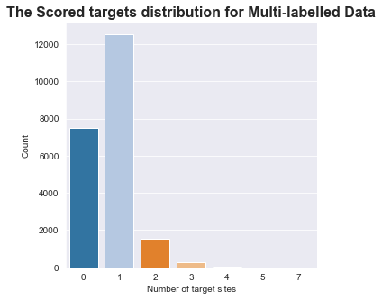

```python
plt.figure(figsize=(5,5))
sns.countplot(new_target_data["y"])

plt.title("The Scored targets distribution for Multi-labelled Data", fontsize=16, weight='bold')
plt.ylabel('Count',fontsize=10)
plt.xlabel('Number of target sites',fontsize=10)
```

```python
new_target_data.loc[new_target_data['y'] > 0, 'y' ]=1
```

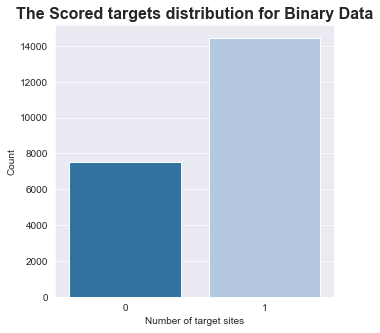

```python
plt.figure(figsize=(5,5))
sns.countplot(new_target_data["y"])
plt.ylabel('Count',fontsize=10)
plt.xlabel('Number of target sites',fontsize=10)

plt.title("The Scored targets distribution for Binary Data", fontsize=16, weight='bold');
```

Multi labelled data is converted to Binary data with catogeries of 0 represents no mechanism of action and 1 represents mechaniosm of action at 1 or more site.